# Analysis

Qiuyufan

11/18/2018

Analysis

#### 1.read the data to R

```r
joined_data <- read.csv(file="alc.csv", header=TRUE)
colnames(joined_data)
```

```
##  [1] "school"     "sex"        "age"        "address"    "famsize"
##  [6] "Pstatus"    "Medu"       "Fedu"       "Mjob"       "Fjob"
## [11] "reason"     "nursery"    "internet"   "guardian"   "traveltime"
## [16] "studytime"  "failures"   "schoolsup"  "famsup"     "paid"
## [21] "activities" "higher"     "romantic"   "famrel"     "freetime"
## [26] "goout"      "Dalc"       "Walc"       "health"     "absences"
## [31] "G1"         "G2"         "G3"         "alc_use"    "high_use"
```

```r
summary(joined_data)
```

```
##  school   sex          age        address famsize   Pstatus
##  GP:342   F:198   Min.   :15.00   R: 81   GT3:278   A: 38
##  MS: 40   M:184   1st Qu.:16.00   U:301   LE3:104   T:344
##                   Median :17.00
##                   Mean   :16.59
##                   3rd Qu.:17.00
##                   Max.   :22.00
##       Medu            Fedu             Mjob           Fjob
##  Min.   :0.000   Min.   :0.000   at_home : 53   at_home : 16
##  1st Qu.:2.000   1st Qu.:2.000   health  : 33   health  : 17
##  Median :3.000   Median :3.000   other   :138   other   :211
##  Mean   :2.806   Mean   :2.565   services: 96   services:107
##  3rd Qu.:4.000   3rd Qu.:4.000   teacher : 62   teacher : 31
##  Max.   :4.000   Max.   :4.000
##         reason    nursery   internet    guardian     traveltime
##  course    :140   no : 72   no : 58   father: 91   Min.   :1.000
##  home      :110   yes:310   yes:324   mother:275   1st Qu.:1.000
##  other     : 34                       other : 16   Median :1.000
##  reputation: 98                                    Mean   :1.448
##                                                    3rd Qu.:2.000
##                                                    Max.   :4.000
##    studytime        failures      schoolsup famsup     paid     activities
##  Min.   :1.000   Min.   :0.0000   no :331   no :144   no :205   no :181
##  1st Qu.:1.000   1st Qu.:0.0000   yes: 51   yes:238   yes:177   yes:201
##  Median :2.000   Median :0.0000
##  Mean   :2.037   Mean   :0.2016
##  3rd Qu.:2.000   3rd Qu.:0.0000
##  Max.   :4.000   Max.   :3.0000
##  higher    romantic      famrel         freetime        goout
##  no : 18   no :261   Min.   :1.000   Min.   :1.00   Min.   :1.000
##  yes:364   yes:121   1st Qu.:4.000   1st Qu.:3.00   1st Qu.:2.000
##                      Median :4.000   Median :3.00   Median :3.000
##                      Mean   :3.937   Mean   :3.22   Mean   :3.113
##                      3rd Qu.:5.000   3rd Qu.:4.00   3rd Qu.:4.000
##                      Max.   :5.000   Max.   :5.00   Max.   :5.000
##       Dalc            Walc           health         absences
##  Min.   :1.000   Min.   :1.000   Min.   :1.000   Min.   : 0.0
##  1st Qu.:1.000   1st Qu.:1.000   1st Qu.:3.000   1st Qu.: 1.0
##  Median :1.000   Median :2.000   Median :4.000   Median : 3.0
##  Mean   :1.482   Mean   :2.296   Mean   :3.573   Mean   : 4.5
##  3rd Qu.:2.000   3rd Qu.:3.000   3rd Qu.:5.000   3rd Qu.: 6.0
##  Max.   :5.000   Max.   :5.000   Max.   :5.000   Max.   :45.0
##        G1              G2              G3           alc_use
##  Min.   : 2.00   Min.   : 4.00   Min.   : 0.00   Min.   :1.000
##  1st Qu.:10.00   1st Qu.:10.00   1st Qu.:10.00   1st Qu.:1.000
##  Median :12.00   Median :12.00   Median :12.00   Median :1.500
##  Mean   :11.49   Mean   :11.47   Mean   :11.46   Mean   :1.889
##  3rd Qu.:14.00   3rd Qu.:14.00   3rd Qu.:14.00   3rd Qu.:2.500
##  Max.   :18.00   Max.   :18.00   Max.   :18.00   Max.   :5.000
##   high_use
##  Mode :logical
##  FALSE:268
##  TRUE :114
##
##
##
```

The data is combined by both student-mat.csv (Math course) and student-por.csv (Portuguese language course) datasets. The data attributes include student grades, demographic, social and school related features) and it was collected by using school reports and questionnaires.

#### 2.Choose 4 interesting variables with alcohol consumption

“sex”, “guardian”,“freetime”,“paid” “sex”: male would have high alcohol consumption, while female have low alcohol consumption “guardian”:as father would have high consumption, with mother have low consumption “freetime”: more free time, high consumption “paid”: more paid, more consumption

#### 3.explore the distributions of the chosen variables and their relationships with alcohol consumption

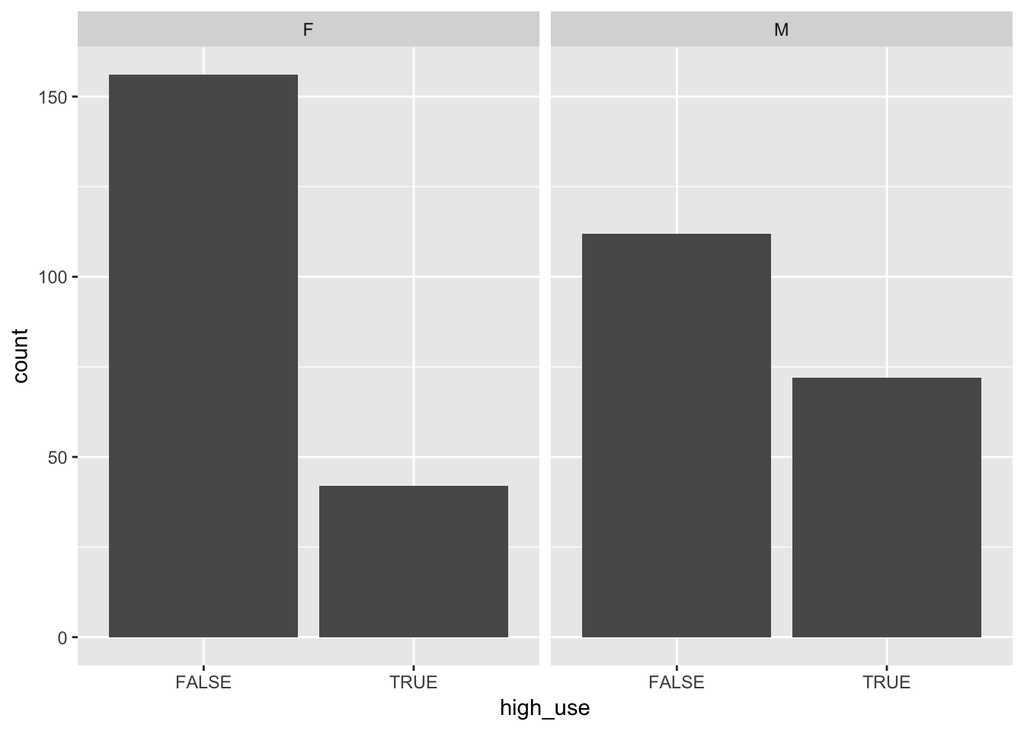

```r
library(ggplot2)
library(dplyr)
g2 <- ggplot(joined_data, aes(high_use))
g2 + facet_wrap("sex") + geom_bar()
```

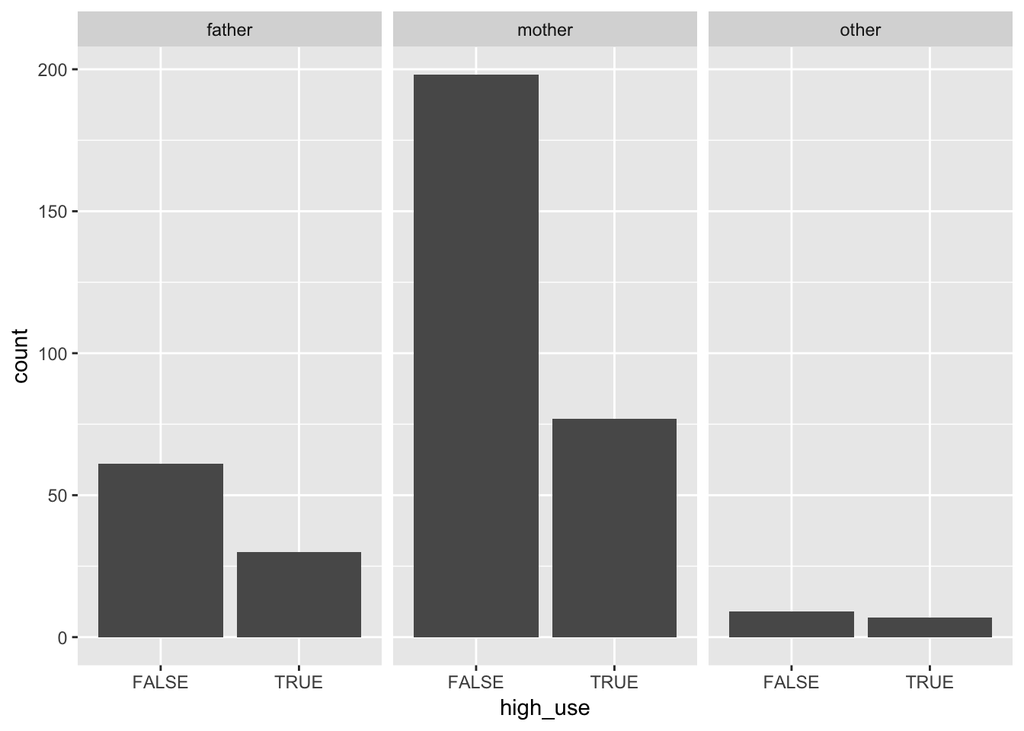

```r
g2 + facet_wrap("guardian") + geom_bar()
```

Plot2 shows that being with mother has less high use alcohol percentage than being with father.

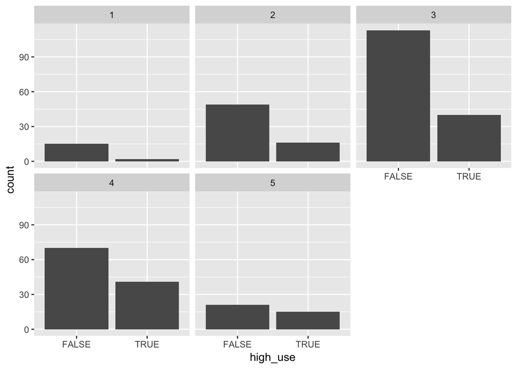

```r
g2 + facet_wrap("freetime") + geom_bar()
```

Plot3 shows that students who enjoy most free time also enjoy the high use alcohol. It seems to be linearly correlated.

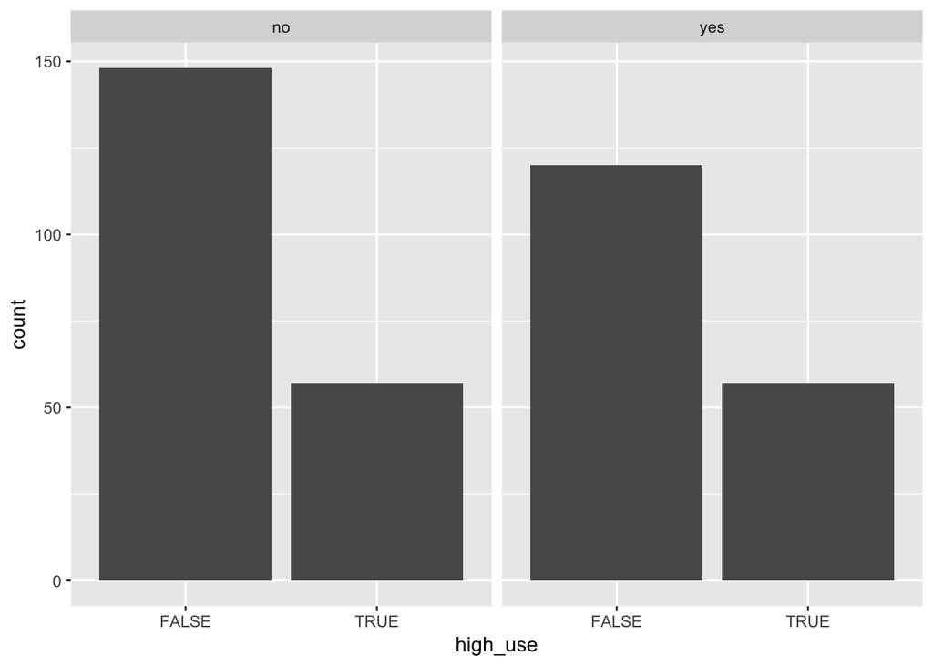

```r
g2 + facet_wrap("paid") + geom_bar()
```

Plot4 shows that students who got paid have a slightly higher high use of alcohol consumption.

#### 4.Using logistic regression to explore the data

```r
m <- glm(high_use ~ freetime + paid + sex + guardian , data = joined_data, family = "binomial")
summary(m)
```

```
##
## Call:
## glm(formula = high_use ~ freetime + paid + sex + guardian, family = "binomial",
##     data = joined_data)
##
## Deviance Residuals:
##     Min       1Q   Median       3Q      Max
## -1.3508  -0.8560  -0.6722   1.2416   2.0250
##
## Coefficients:
##                Estimate Std. Error z value Pr(>|z|)
## (Intercept)     -2.2203     0.4881  -4.549  5.4e-06 ***
## freetime         0.2701     0.1225   2.206 0.027387 *
## paidyes          0.3954     0.2356   1.678 0.093323 .
## sexM             0.8272     0.2400   3.446 0.000568 ***
## guardianmother  -0.2326     0.2696  -0.863 0.388217
## guardianother    0.4411     0.5705   0.773 0.439404
## ---
## Signif. codes:  0 '***' 0.001 '**' 0.01 '*' 0.05 '.' 0.1 ' ' 1
##
## (Dispersion parameter for binomial family taken to be 1)
##
##     Null deviance: 465.68  on 381  degrees of freedom
## Residual deviance: 441.35  on 376  degrees of freedom
## AIC: 453.35
##
## Number of Fisher Scoring iterations: 4
```

```r
coef(m)
```

```
##    (Intercept)       freetime        paidyes           sexM guardianmother
##     -2.2203148      0.2701489      0.3954381      0.8272337     -0.2326226
##  guardianother
##      0.4410948
```

#### 5.prediction with model

```r
probabilities <- predict(m, type = "response")
joined_data <- mutate(joined_data, probability = probabilities)
joined_data <- mutate(joined_data, prediction = probability > 0.5)
select(joined_data, freetime, paid, sex,guardian, probability, prediction) %>% tail(10)
```

```
##     freetime paid sex guardian probability prediction
## 373        3   no   M   mother   0.3067714      FALSE
## 374        4  yes   M   father   0.5207263       TRUE
## 375        3  yes   F   mother   0.2232108      FALSE
## 376        4  yes   F   mother   0.2735066      FALSE
## 377        4   no   F   mother   0.2022418      FALSE
## 378        3  yes   F   mother   0.2232108      FALSE
## 379        2   no   F   mother   0.1286846      FALSE
## 380        1   no   F   mother   0.1013068      FALSE
## 381        4   no   M   mother   0.3670001      FALSE
## 382        4   no   M   mother   0.3670001      FALSE
```

```r
table(high_use = joined_data$high_use, prediction = joined_data$prediction)
```

```
##         prediction
## high_use FALSE TRUE
##    FALSE   258   10
##    TRUE    103   11
```

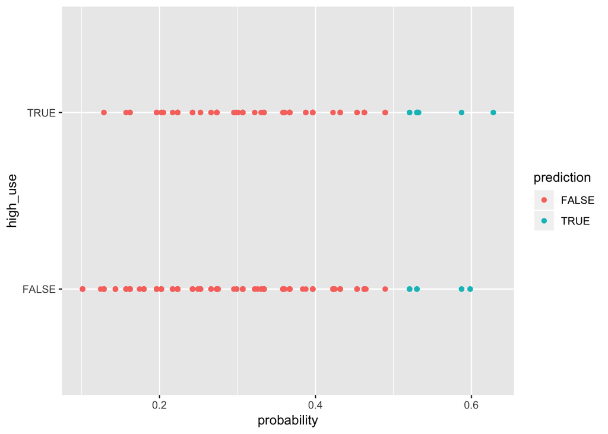

```r
g <- ggplot(joined_data, aes(x = probability, y = high_use, col = prediction))
g + geom_point()
```

```r
table(high_use = joined_data$high_use, prediction = joined_data$prediction) %>% prop.table %>% addmargins
```

```
##         prediction
## high_use      FALSE       TRUE        Sum
##    FALSE 0.67539267 0.02617801 0.70157068
##    TRUE  0.26963351 0.02879581 0.29842932
##    Sum   0.94502618 0.05497382 1.00000000
```

```r
loss_func <- function(class, prob) {
  n_wrong <- abs(class - prob) > 0.5
  mean(n_wrong)
}
loss_func(class = joined_data$high_use, prob = joined_data$probability)
```

```
## [1] 0.2958115
```

average number of incorrect predictions is 0.2958

#### 6.Perform 10-fold cross-validation on my model

```r
library(boot)
cv <- cv.glm(data = joined_data, cost = loss_func, glmfit = m, K = 10)
cv$delta[1]
```

```
## [1] 0.2984293
```